# Risk Factor Analysis

## Outcome Variable

**Outcome Variable:** wasted

## Predictor Variables

**Intervention Variable:** brthmon

**Adjustment Set:**

unadjusted

## Stratifying Variables

The analysis was stratified on these variable(s):

- agecat
- studyid
- country

## Data Summary

| agecat | studyid | country | brthmon | wasted | n_cell | n |
| --- | --- | --- | --- | --- | --- | --- |
| Birth | CMC-V-BCS-2002 | INDIA | 1 | 0 | 8 | 86 |
| Birth | CMC-V-BCS-2002 | INDIA | 1 | 1 | 1 | 86 |
| Birth | CMC-V-BCS-2002 | INDIA | 2 | 0 | 0 | 86 |
| Birth | CMC-V-BCS-2002 | INDIA | 2 | 1 | 1 | 86 |
| Birth | CMC-V-BCS-2002 | INDIA | 3 | 0 | 6 | 86 |
| Birth | CMC-V-BCS-2002 | INDIA | 3 | 1 | 1 | 86 |
| Birth | CMC-V-BCS-2002 | INDIA | 4 | 0 | 9 | 86 |
| Birth | CMC-V-BCS-2002 | INDIA | 4 | 1 | 0 | 86 |
| Birth | CMC-V-BCS-2002 | INDIA | 5 | 0 | 10 | 86 |
| Birth | CMC-V-BCS-2002 | INDIA | 5 | 1 | 0 | 86 |
| Birth | CMC-V-BCS-2002 | INDIA | 6 | 0 | 8 | 86 |
| Birth | CMC-V-BCS-2002 | INDIA | 6 | 1 | 1 | 86 |
| Birth | CMC-V-BCS-2002 | INDIA | 7 | 0 | 7 | 86 |
| Birth | CMC-V-BCS-2002 | INDIA | 7 | 1 | 0 | 86 |
| Birth | CMC-V-BCS-2002 | INDIA | 8 | 0 | 4 | 86 |
| Birth | CMC-V-BCS-2002 | INDIA | 8 | 1 | 0 | 86 |
| Birth | CMC-V-BCS-2002 | INDIA | 9 | 0 | 6 | 86 |
| Birth | CMC-V-BCS-2002 | INDIA | 9 | 1 | 2 | 86 |
| Birth | CMC-V-BCS-2002 | INDIA | 10 | 0 | 7 | 86 |
| Birth | CMC-V-BCS-2002 | INDIA | 10 | 1 | 1 | 86 |
| Birth | CMC-V-BCS-2002 | INDIA | 11 | 0 | 8 | 86 |
| Birth | CMC-V-BCS-2002 | INDIA | 11 | 1 | 3 | 86 |
| Birth | CMC-V-BCS-2002 | INDIA | 12 | 0 | 2 | 86 |
| Birth | CMC-V-BCS-2002 | INDIA | 12 | 1 | 1 | 86 |
| Birth | CMIN | BANGLADESH | 1 | 0 | 2 | 19 |
| Birth | CMIN | BANGLADESH | 1 | 1 | 0 | 19 |
| Birth | CMIN | BANGLADESH | 2 | 0 | 3 | 19 |
| Birth | CMIN | BANGLADESH | 2 | 1 | 1 | 19 |
| Birth | CMIN | BANGLADESH | 3 | 0 | 0 | 19 |
| Birth | CMIN | BANGLADESH | 3 | 1 | 0 | 19 |

[output cut: 1506 more lines]

The following strata were considered:

- agecat: 24 months, studyid: CMC-V-BCS-2002, country: INDIA
- agecat: 24 months, studyid: CMIN, country: BANGLADESH
- agecat: 24 months, studyid: CONTENT, country: PERU
- agecat: 24 months, studyid: EE, country: PAKISTAN
- agecat: 24 months, studyid: GMS-Nepal, country: NEPAL
- agecat: 24 months, studyid: IRC, country: INDIA
- agecat: 24 months, studyid: Keneba, country: GAMBIA
- agecat: 24 months, studyid: LCNI-5, country: MALAWI
- agecat: 24 months, studyid: MAL-ED, country: BANGLADESH
- agecat: 24 months, studyid: MAL-ED, country: BRAZIL
- agecat: 24 months, studyid: MAL-ED, country: INDIA
- agecat: 24 months, studyid: MAL-ED, country: NEPAL
- agecat: 24 months, studyid: MAL-ED, country: PERU
- agecat: 24 months, studyid: MAL-ED, country: SOUTH AFRICA
- agecat: 24 months, studyid: MAL-ED, country: TANZANIA, UNITED REPUBLIC OF
- agecat: 24 months, studyid: NIH-Birth, country: BANGLADESH
- agecat: 24 months, studyid: PROBIT, country: BELARUS
- agecat: 24 months, studyid: PROVIDE, country: BANGLADESH
- agecat: 24 months, studyid: TanzaniaChild2, country: TANZANIA, UNITED REPUBLIC OF
- agecat: 24 months, studyid: ZVITAMBO, country: ZIMBABWE
- agecat: 6 months, studyid: CMC-V-BCS-2002, country: INDIA
- agecat: 6 months, studyid: CMIN, country: BANGLADESH
- agecat: 6 months, studyid: CONTENT, country: PERU
- agecat: 6 months, studyid: EE, country: PAKISTAN
- agecat: 6 months, studyid: GMS-Nepal, country: NEPAL
- agecat: 6 months, studyid: Guatemala BSC, country: GUATEMALA
- agecat: 6 months, studyid: IRC, country: INDIA
- agecat: 6 months, studyid: Keneba, country: GAMBIA
- agecat: 6 months, studyid: LCNI-5, country: MALAWI
- agecat: 6 months, studyid: MAL-ED, country: BANGLADESH
- agecat: 6 months, studyid: MAL-ED, country: BRAZIL
- agecat: 6 months, studyid: MAL-ED, country: INDIA
- agecat: 6 months, studyid: MAL-ED, country: NEPAL
- agecat: 6 months, studyid: MAL-ED, country: PERU
- agecat: 6 months, studyid: MAL-ED, country: SOUTH AFRICA
- agecat: 6 months, studyid: MAL-ED, country: TANZANIA, UNITED REPUBLIC OF
- agecat: 6 months, studyid: NIH-Birth, country: BANGLADESH
- agecat: 6 months, studyid: PROBIT, country: BELARUS
- agecat: 6 months, studyid: PROVIDE, country: BANGLADESH
- agecat: 6 months, studyid: ResPak, country: PAKISTAN
- agecat: 6 months, studyid: SAS-CompFeed, country: INDIA
- agecat: 6 months, studyid: SAS-FoodSuppl, country: INDIA
- agecat: 6 months, studyid: TanzaniaChild2, country: TANZANIA, UNITED REPUBLIC OF
- agecat: 6 months, studyid: ZVITAMBO, country: ZIMBABWE
- agecat: Birth, studyid: CMC-V-BCS-2002, country: INDIA
- agecat: Birth, studyid: CMIN, country: BANGLADESH
- agecat: Birth, studyid: CONTENT, country: PERU
- agecat: Birth, studyid: EE, country: PAKISTAN
- agecat: Birth, studyid: GMS-Nepal, country: NEPAL
- agecat: Birth, studyid: IRC, country: INDIA
- agecat: Birth, studyid: Keneba, country: GAMBIA
- agecat: Birth, studyid: MAL-ED, country: BANGLADESH
- agecat: Birth, studyid: MAL-ED, country: BRAZIL
- agecat: Birth, studyid: MAL-ED, country: INDIA
- agecat: Birth, studyid: MAL-ED, country: NEPAL
- agecat: Birth, studyid: MAL-ED, country: PERU
- agecat: Birth, studyid: MAL-ED, country: SOUTH AFRICA
- agecat: Birth, studyid: MAL-ED, country: TANZANIA, UNITED REPUBLIC OF
- agecat: Birth, studyid: NIH-Birth, country: BANGLADESH
- agecat: Birth, studyid: PROBIT, country: BELARUS
- agecat: Birth, studyid: PROVIDE, country: BANGLADESH
- agecat: Birth, studyid: ResPak, country: PAKISTAN
- agecat: Birth, studyid: SAS-CompFeed, country: INDIA
- agecat: Birth, studyid: ZVITAMBO, country: ZIMBABWE

### Dropped Strata

Some strata were dropped due to rare outcomes:

- agecat: Birth, studyid: CMC-V-BCS-2002, country: INDIA
- agecat: Birth, studyid: CMIN, country: BANGLADESH
- agecat: Birth, studyid: CONTENT, country: PERU
- agecat: Birth, studyid: EE, country: PAKISTAN
- agecat: Birth, studyid: GMS-Nepal, country: NEPAL
- agecat: Birth, studyid: IRC, country: INDIA
- agecat: Birth, studyid: MAL-ED, country: BANGLADESH
- agecat: Birth, studyid: MAL-ED, country: BRAZIL
- agecat: Birth, studyid: MAL-ED, country: INDIA
- agecat: Birth, studyid: MAL-ED, country: NEPAL
- agecat: Birth, studyid: MAL-ED, country: PERU
- agecat: Birth, studyid: MAL-ED, country: SOUTH AFRICA
- agecat: Birth, studyid: MAL-ED, country: TANZANIA, UNITED REPUBLIC OF
- agecat: Birth, studyid: PROVIDE, country: BANGLADESH
- agecat: Birth, studyid: ResPak, country: PAKISTAN
- agecat: Birth, studyid: SAS-CompFeed, country: INDIA
- agecat: 6 months, studyid: CMC-V-BCS-2002, country: INDIA
- agecat: 6 months, studyid: CMIN, country: BANGLADESH
- agecat: 6 months, studyid: CONTENT, country: PERU
- agecat: 6 months, studyid: EE, country: PAKISTAN
- agecat: 6 months, studyid: GMS-Nepal, country: NEPAL
- agecat: 6 months, studyid: Guatemala BSC, country: GUATEMALA
- agecat: 6 months, studyid: IRC, country: INDIA
- agecat: 6 months, studyid: LCNI-5, country: MALAWI
- agecat: 6 months, studyid: MAL-ED, country: BANGLADESH
- agecat: 6 months, studyid: MAL-ED, country: BRAZIL
- agecat: 6 months, studyid: MAL-ED, country: INDIA
- agecat: 6 months, studyid: MAL-ED, country: NEPAL
- agecat: 6 months, studyid: MAL-ED, country: PERU
- agecat: 6 months, studyid: MAL-ED, country: SOUTH AFRICA
- agecat: 6 months, studyid: MAL-ED, country: TANZANIA, UNITED REPUBLIC OF
- agecat: 6 months, studyid: NIH-Birth, country: BANGLADESH
- agecat: 6 months, studyid: PROBIT, country: BELARUS
- agecat: 6 months, studyid: PROVIDE, country: BANGLADESH
- agecat: 6 months, studyid: ResPak, country: PAKISTAN
- agecat: 6 months, studyid: SAS-CompFeed, country: INDIA
- agecat: 6 months, studyid: SAS-FoodSuppl, country: INDIA
- agecat: 6 months, studyid: TanzaniaChild2, country: TANZANIA, UNITED REPUBLIC OF
- agecat: 24 months, studyid: CMC-V-BCS-2002, country: INDIA
- agecat: 24 months, studyid: CMIN, country: BANGLADESH
- agecat: 24 months, studyid: CONTENT, country: PERU
- agecat: 24 months, studyid: EE, country: PAKISTAN
- agecat: 24 months, studyid: GMS-Nepal, country: NEPAL
- agecat: 24 months, studyid: IRC, country: INDIA
- agecat: 24 months, studyid: LCNI-5, country: MALAWI
- agecat: 24 months, studyid: MAL-ED, country: BANGLADESH
- agecat: 24 months, studyid: MAL-ED, country: BRAZIL
- agecat: 24 months, studyid: MAL-ED, country: INDIA
- agecat: 24 months, studyid: MAL-ED, country: NEPAL
- agecat: 24 months, studyid: MAL-ED, country: PERU
- agecat: 24 months, studyid: MAL-ED, country: SOUTH AFRICA
- agecat: 24 months, studyid: MAL-ED, country: TANZANIA, UNITED REPUBLIC OF
- agecat: 24 months, studyid: NIH-Birth, country: BANGLADESH
- agecat: 24 months, studyid: PROBIT, country: BELARUS
- agecat: 24 months, studyid: PROVIDE, country: BANGLADESH
- agecat: 24 months, studyid: TanzaniaChild2, country: TANZANIA, UNITED REPUBLIC OF
- agecat: 24 months, studyid: ZVITAMBO, country: ZIMBABWE

## Methods Detail

We’re interested in the causal parameters $E[Y_a]$ for all values of $a \in \mathcal{A}$. These parameters represent the mean outcome if, possibly contrary to fact, we intervened to set all units to have $A=a$. Under the randomization and positivity assumptions, these are identified by the statistical parameters $\psi_a=E_W[E_{Y|A,W}(Y|A=a,W)]$. In addition, we’re interested in the mean of $Y$, $E[Y]$ under no intervention (the observed mean). We will estimate these parameters by using SuperLearner to fit the relevant likelihood factors – $E_{Y|A,W}(Y|A=a,W)$ and $p(A=a|W)$, and then updating our likelihood fit using a joint TMLE.

For unadjusted analyses ($W=\{\}$), initial likelihoods were estimated using Lrnr_glm to estimate the simple $E(Y|A)$ and Lrnr_mean to estimate $p(A)$. For adjusted analyses, a small library containing Lrnr_glmnet, Lrnr_xgboost, and Lrnr_mean was used.

Having estimated these parameters, we will then use the delta method to estimate relative risks and attributable risks relative to a prespecified baseline level of $A$.

# Results Detail

## Results Plots

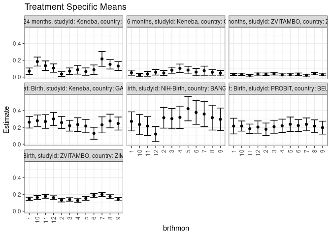

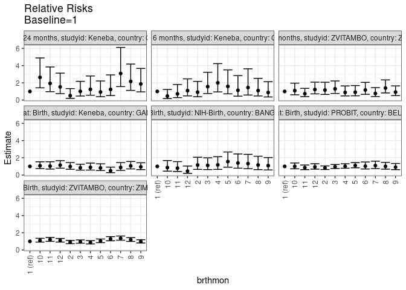

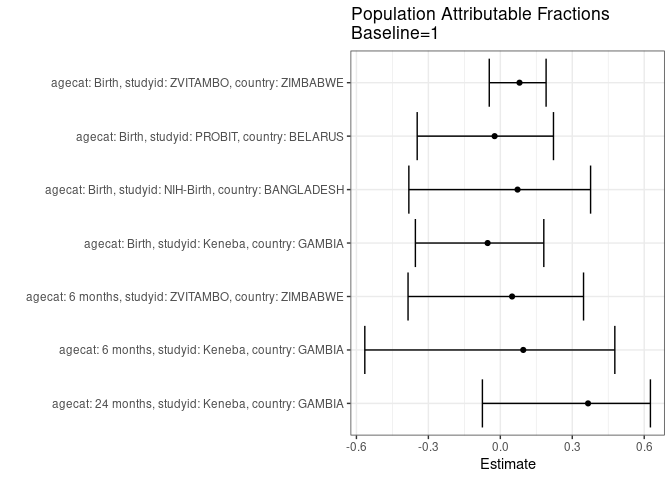

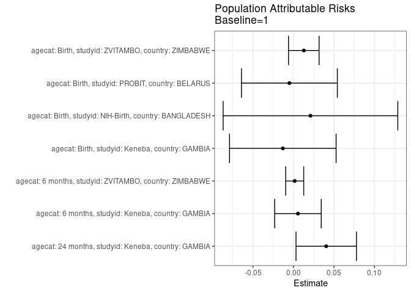

## Results Table

### Parameter: TSM

| agecat | studyid | country | intervention_level | baseline_level | estimate | ci_lower | ci_upper |
| --- | --- | --- | --- | --- | --- | --- | --- |
| Birth | Keneba | GAMBIA | 1 | NA | 0.2614379 | 0.1917868 | 0.3310891 |
| Birth | Keneba | GAMBIA | 2 | NA | 0.2571429 | 0.1847206 | 0.3295651 |
| Birth | Keneba | GAMBIA | 3 | NA | 0.2201258 | 0.1557021 | 0.2845495 |
| Birth | Keneba | GAMBIA | 4 | NA | 0.2330097 | 0.1513403 | 0.3146792 |
| Birth | Keneba | GAMBIA | 5 | NA | 0.2156863 | 0.1358404 | 0.2955321 |
| Birth | Keneba | GAMBIA | 6 | NA | 0.1294118 | 0.0580312 | 0.2007923 |
| Birth | Keneba | GAMBIA | 7 | NA | 0.2297297 | 0.1338536 | 0.3256059 |
| Birth | Keneba | GAMBIA | 8 | NA | 0.2758621 | 0.1944996 | 0.3572245 |
| Birth | Keneba | GAMBIA | 9 | NA | 0.2457627 | 0.1680544 | 0.3234710 |
| Birth | Keneba | GAMBIA | 10 | NA | 0.2797619 | 0.2118613 | 0.3476626 |
| Birth | Keneba | GAMBIA | 11 | NA | 0.2695652 | 0.1884374 | 0.3506931 |
| Birth | Keneba | GAMBIA | 12 | NA | 0.3007519 | 0.2227886 | 0.3787152 |
| Birth | NIH-Birth | BANGLADESH | 1 | NA | 0.2711864 | 0.1576482 | 0.3847247 |
| Birth | NIH-Birth | BANGLADESH | 2 | NA | 0.3148148 | 0.1908322 | 0.4387974 |
| Birth | NIH-Birth | BANGLADESH | 3 | NA | 0.3035714 | 0.1830399 | 0.4241030 |
| Birth | NIH-Birth | BANGLADESH | 4 | NA | 0.3191489 | 0.1857661 | 0.4525318 |
| Birth | NIH-Birth | BANGLADESH | 5 | NA | 0.4222222 | 0.2777878 | 0.5666567 |
| Birth | NIH-Birth | BANGLADESH | 6 | NA | 0.3777778 | 0.2359991 | 0.5195564 |
| Birth | NIH-Birth | BANGLADESH | 7 | NA | 0.3589744 | 0.2082917 | 0.5096570 |
| Birth | NIH-Birth | BANGLADESH | 8 | NA | 0.3157895 | 0.1678691 | 0.4637098 |
| Birth | NIH-Birth | BANGLADESH | 9 | NA | 0.2954545 | 0.1605273 | 0.4303818 |
| Birth | NIH-Birth | BANGLADESH | 10 | NA | 0.2340426 | 0.1128916 | 0.3551935 |
| Birth | NIH-Birth | BANGLADESH | 11 | NA | 0.2156863 | 0.1027074 | 0.3286651 |
| Birth | NIH-Birth | BANGLADESH | 12 | NA | 0.1200000 | 0.0298485 | 0.2101515 |
| Birth | PROBIT | BELARUS | 1 | NA | 0.2153285 | 0.1216542 | 0.3090027 |
| Birth | PROBIT | BELARUS | 2 | NA | 0.1769134 | 0.1022202 | 0.2516066 |
| Birth | PROBIT | BELARUS | 3 | NA | 0.2072264 | 0.1296002 | 0.2848525 |
| Birth | PROBIT | BELARUS | 4 | NA | 0.2185567 | 0.1390159 | 0.2980975 |
| Birth | PROBIT | BELARUS | 5 | NA | 0.2367304 | 0.1501816 | 0.3232791 |
| Birth | PROBIT | BELARUS | 6 | NA | 0.2215686 | 0.1502359 | 0.2929013 |

[output cut: 54 more lines]

### Parameter: E(Y)

| agecat | studyid | country | intervention_level | baseline_level | estimate | ci_lower | ci_upper |
| --- | --- | --- | --- | --- | --- | --- | --- |
| Birth | Keneba | GAMBIA | NA | NA | 0.2482947 | 0.2261720 | 0.2704173 |
| Birth | NIH-Birth | BANGLADESH | NA | NA | 0.2921739 | 0.2549711 | 0.3293768 |
| Birth | PROBIT | BELARUS | NA | NA | 0.2103206 | 0.1450833 | 0.2755580 |
| Birth | ZVITAMBO | ZIMBABWE | NA | NA | 0.1595572 | 0.1532418 | 0.1658725 |
| 6 months | Keneba | GAMBIA | NA | NA | 0.0579225 | 0.0479029 | 0.0679420 |
| 6 months | ZVITAMBO | ZIMBABWE | NA | NA | 0.0311581 | 0.0274654 | 0.0348509 |
| 24 months | Keneba | GAMBIA | NA | NA | 0.1106605 | 0.0958563 | 0.1254646 |

### Parameter: RR

| agecat | studyid | country | intervention_level | baseline_level | estimate | ci_lower | ci_upper |
| --- | --- | --- | --- | --- | --- | --- | --- |
| Birth | Keneba | GAMBIA | 1 | 1 | 1.0000000 | 1.0000000 | 1.0000000 |
| Birth | Keneba | GAMBIA | 2 | 1 | 0.9835714 | 0.6674773 | 1.4493569 |
| Birth | Keneba | GAMBIA | 3 | 1 | 0.8419811 | 0.5667909 | 1.2507826 |
| Birth | Keneba | GAMBIA | 4 | 1 | 0.8912621 | 0.5738578 | 1.3842248 |
| Birth | Keneba | GAMBIA | 5 | 1 | 0.8250000 | 0.5228476 | 1.3017656 |
| Birth | Keneba | GAMBIA | 6 | 1 | 0.4950000 | 0.2682743 | 0.9133375 |
| Birth | Keneba | GAMBIA | 7 | 1 | 0.8787162 | 0.5355708 | 1.4417183 |
| Birth | Keneba | GAMBIA | 8 | 1 | 1.0551724 | 0.7091094 | 1.5701228 |
| Birth | Keneba | GAMBIA | 9 | 1 | 0.9400424 | 0.6217002 | 1.4213918 |
| Birth | Keneba | GAMBIA | 10 | 1 | 1.0700893 | 0.7462808 | 1.5343970 |
| Birth | Keneba | GAMBIA | 11 | 1 | 1.0310870 | 0.6898210 | 1.5411830 |
| Birth | Keneba | GAMBIA | 12 | 1 | 1.1503759 | 0.7932378 | 1.6683077 |
| Birth | NIH-Birth | BANGLADESH | 1 | 1 | 1.0000000 | 1.0000000 | 1.0000000 |
| Birth | NIH-Birth | BANGLADESH | 2 | 1 | 1.1608796 | 0.6533682 | 2.0626064 |
| Birth | NIH-Birth | BANGLADESH | 3 | 1 | 1.1194196 | 0.6286430 | 1.9933417 |
| Birth | NIH-Birth | BANGLADESH | 4 | 1 | 1.1768617 | 0.6513435 | 2.1263795 |
| Birth | NIH-Birth | BANGLADESH | 5 | 1 | 1.5569444 | 0.9067138 | 2.6734743 |
| Birth | NIH-Birth | BANGLADESH | 6 | 1 | 1.3930556 | 0.7939313 | 2.4442967 |
| Birth | NIH-Birth | BANGLADESH | 7 | 1 | 1.3237179 | 0.7316768 | 2.3948132 |
| Birth | NIH-Birth | BANGLADESH | 8 | 1 | 1.1644737 | 0.6212751 | 2.1826063 |
| Birth | NIH-Birth | BANGLADESH | 9 | 1 | 1.0894886 | 0.5863491 | 2.0243665 |
| Birth | NIH-Birth | BANGLADESH | 10 | 1 | 0.8630319 | 0.4434951 | 1.6794415 |
| Birth | NIH-Birth | BANGLADESH | 11 | 1 | 0.7953431 | 0.4067519 | 1.5551759 |
| Birth | NIH-Birth | BANGLADESH | 12 | 1 | 0.4425000 | 0.1872403 | 1.0457485 |
| Birth | PROBIT | BELARUS | 1 | 1 | 1.0000000 | 1.0000000 | 1.0000000 |
| Birth | PROBIT | BELARUS | 2 | 1 | 0.8215979 | 0.6380707 | 1.0579128 |
| Birth | PROBIT | BELARUS | 3 | 1 | 0.9623732 | 0.7578054 | 1.2221637 |
| Birth | PROBIT | BELARUS | 4 | 1 | 1.0149921 | 0.7888452 | 1.3059711 |
| Birth | PROBIT | BELARUS | 5 | 1 | 1.0993918 | 0.8391282 | 1.4403788 |
| Birth | PROBIT | BELARUS | 6 | 1 | 1.0289797 | 0.6989223 | 1.5149026 |

[output cut: 54 more lines]

### Parameter: PAR

| agecat | studyid | country | intervention_level | baseline_level | estimate | ci_lower | ci_upper |
| --- | --- | --- | --- | --- | --- | --- | --- |
| Birth | Keneba | GAMBIA | 1 | NA | -0.0131432 | -0.0789314 | 0.0526449 |
| Birth | NIH-Birth | BANGLADESH | 1 | NA | 0.0209875 | -0.0868529 | 0.1288278 |
| Birth | PROBIT | BELARUS | 1 | NA | -0.0050078 | -0.0642097 | 0.0541940 |
| Birth | ZVITAMBO | ZIMBABWE | 1 | NA | 0.0127607 | -0.0060973 | 0.0316188 |
| 6 months | Keneba | GAMBIA | 1 | NA | 0.0055415 | -0.0232019 | 0.0342848 |
| 6 months | ZVITAMBO | ZIMBABWE | 1 | NA | 0.0015285 | -0.0096085 | 0.0126655 |
| 24 months | Keneba | GAMBIA | 1 | NA | 0.0404850 | 0.0031322 | 0.0778379 |

### Parameter: PAF

| agecat | studyid | country | intervention_level | baseline_level | estimate | ci_lower | ci_upper |
| --- | --- | --- | --- | --- | --- | --- | --- |
| Birth | Keneba | GAMBIA | 1 | NA | -0.0529340 | -0.3541962 | 0.1813077 |
| Birth | NIH-Birth | BANGLADESH | 1 | NA | 0.0718321 | -0.3813899 | 0.3763559 |
| Birth | PROBIT | BELARUS | 1 | NA | -0.0238105 | -0.3466434 | 0.2216291 |
| Birth | ZVITAMBO | ZIMBABWE | 1 | NA | 0.0799760 | -0.0461097 | 0.1908647 |
| 6 months | Keneba | GAMBIA | 1 | NA | 0.0956710 | -0.5650275 | 0.4774463 |
| 6 months | ZVITAMBO | ZIMBABWE | 1 | NA | 0.0490566 | -0.3847596 | 0.3469673 |
| 24 months | Keneba | GAMBIA | 1 | NA | 0.3658492 | -0.0747368 | 0.6258179 |